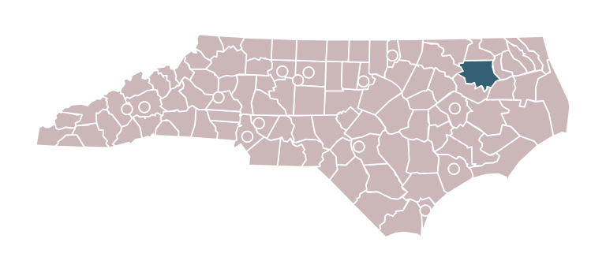

# Bertie County, Spring 2026

## Payments

**Bertie County** is set to receive approximately **$1.68M** in opioid settlement funds from 2022 through 2038. They have received **$501K** to date with **$1.18M** more anticipated.

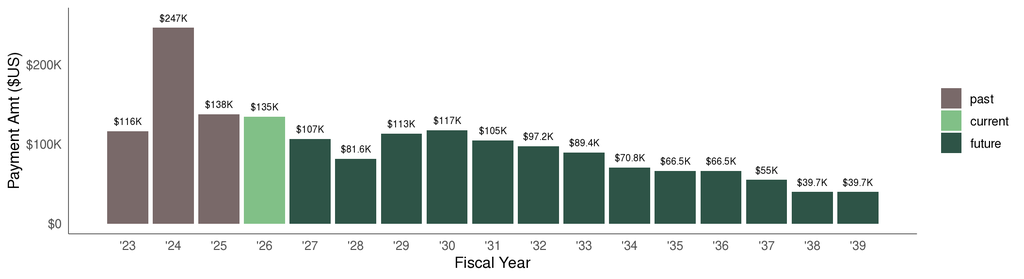

## Spending Plans

**Bertie County** has not shared any spending plans.

Local governments must approve and share **spending plans** before spending opioid settlement funds. Local governments may not spend more than the approved amounts (although they may spend less). Exhibit A strategies are high-impact strategies for addressing the opioid overdose epidemic; Exhibit B strategies are from the national settlement agreements and are available to local governments after participating in a Collaborative Strategic Planning process.

## Collaborative Strategic Planning Reports and Recommendations

Local govenments that wish to spend opioid settlement funds on any Exhibit B strategies must first engage in the Collaborative Strategic Planning process, resulting in a report and recommendations document submitted to the local governing board. This process is not required before authorizing spending on Exhibit A strategies.

**Bertie County** has not submitted any report and recommendations documents.

## Past Spending

As of Summer 2025, **Bertie County** has not reported spending any settlement funds.

**Bertie County** has not spent any settlement funds.

As a state, **North Carolina** has spent a total of **$70.7M** ; the top three most-funded strategies are **Recovery Support Services** ( 56 gov’ts, $19.6M ), **Evidence-Based Addiction Treatment** ( 39 gov’ts, $8.64M ), and **Post-Overdose Response Team** ( 36 gov’ts, $8.08M ).

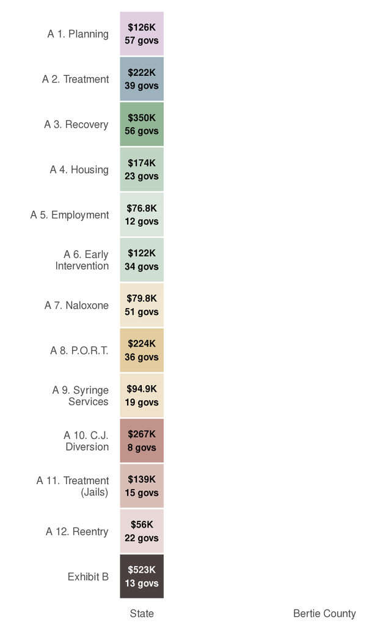

Spending through Summer 2025

Bertie County has not yet reported spending any settlement funds.

## Annual Settlement Update

### Narratives and Success Stories

You can read all of [Bertie County’s progress narratives and success stories](https://p3-repo-dept-core-nc.apps.cloudapps.unc.edu/?govt=Bertie,county&doc_type=narrative) in the Document Library.

### Implementation Scale

Local governments are at varying stages of implementing opioid settlement strategies. For each funded strategy, local governments were asked to selec their State of Implementation from a list of 5 options:

- Exploration and Planning
- Preparation
- Initial Implementation
- Full Implementation
- Further Expansion

Below is the most-advanced stage that **Bertie County** has reported for each funded strategy:

[figure not shown]

## Local Contacts

**Juan E. Vaughan, II** , County Manager  
Bertie County  
juan.vaughan@bertie.nc.gov  
[Bertie County website](http://www.co.bertie.nc.us/)